# Project #1

Kenneth Andrysiak, Joel Revo, Alec Palo, Jacob Cohen, Michael McLaughlan

2/10/2021

# 1 Introduction

A number of different variables in the data seem to have relevant business takeaways. In this section, we will analyze these relationships and provide visualizations of the relationships between the variables.

To begin, we will do some basic descriptive analytics on a number of different variables that we think have some pretty significant business insights.

## 1.1 Data Import and Basic Sturcture Visualization

```r
hotel<-read.csv("hotel_bookings.csv")
library(ggplot2)
```

## 1.2 Data Cleaning

```r
hotel$arrival_date_year<-as.factor(hotel$arrival_date_year)
hotel$arrival_date_month<-as.factor(hotel$arrival_date_month)
hotel$arrival_date_day_of_month<-as.factor(hotel$arrival_date_day_of_month)
hotel$arrival_date_week_number<-as.factor(hotel$arrival_date_week_number)
hotel$is_repeated_guest<-as.factor(hotel$is_repeated_guest)
```

```r
hotel$meal<-as.factor(hotel$meal)
hotel$country<-as.factor(hotel$meal)
hotel$market_segment<-as.factor(hotel$market_segment)
hotel$distribution_channel<-as.factor(hotel$distribution_channel)
hotel$reserved_room_type<-as.factor(hotel$reserved_room_type)
hotel$assigned_room_type<-as.factor(hotel$assigned_room_type)
hotel$deposit_type<-as.factor(hotel$deposit_type)
hotel$agent<-as.factor(hotel$agent)
hotel$company<-as.factor(hotel$company)
hotel$customer_type<-as.factor(hotel$customer_type)
hotel$reservation_status<-as.factor(hotel$reservation_status)
hotel$reservation_status_date<-as.factor(hotel$reservation_status_date)
```

## 1.3 Basic Data Visualization

```r
summary(hotel)
```

```
##     hotel            is_canceled       lead_time   arrival_date_year
##  Length:119390      Min.   :0.0000   Min.   :  0   2015:21996
##  Class :character   1st Qu.:0.0000   1st Qu.: 18   2016:56707
##  Mode  :character   Median :0.0000   Median : 69   2017:40687
##                     Mean   :0.3704   Mean   :104
##                     3rd Qu.:1.0000   3rd Qu.:160
##                     Max.   :1.0000   Max.   :737
##
##  arrival_date_month arrival_date_week_number arrival_date_day_of_month
##  August :13877      33     :  3580           17     : 4406
##  July   :12661      30     :  3087           5      : 4317
##  May    :11791      32     :  3045           15     : 4196
##  October:11160      34     :  3040           25     : 4160
##  April  :11089      18     :  2926           26     : 4147
##  June   :10939      21     :  2854           9      : 4096
##  (Other):47873      (Other):100858           (Other):94068
##  stays_in_weekend_nights stays_in_week_nights     adults
##  Min.   : 0.0000         Min.   : 0.0         Min.   : 0.000
##  1st Qu.: 0.0000         1st Qu.: 1.0         1st Qu.: 2.000
##  Median : 1.0000         Median : 2.0         Median : 2.000
##  Mean   : 0.9276         Mean   : 2.5         Mean   : 1.856
##  3rd Qu.: 2.0000         3rd Qu.: 3.0         3rd Qu.: 2.000
##  Max.   :19.0000         Max.   :50.0         Max.   :55.000
##
##     children           babies                 meal            country
##  Min.   : 0.0000   Min.   : 0.000000   BB       :92310   BB       :92310
##  1st Qu.: 0.0000   1st Qu.: 0.000000   FB       :  798   FB       :  798
##  Median : 0.0000   Median : 0.000000   HB       :14463   HB       :14463
##  Mean   : 0.1039   Mean   : 0.007949   SC       :10650   SC       :10650
##  3rd Qu.: 0.0000   3rd Qu.: 0.000000   Undefined: 1169   Undefined: 1169
##  Max.   :10.0000   Max.   :10.000000
##  NA's   :4
##        market_segment  distribution_channel is_repeated_guest
##  Online TA    :56477   Corporate: 6677      0:115580
##  Offline TA/TO:24219   Direct   :14645      1:  3810
##  Groups       :19811   GDS      :  193
##  Direct       :12606   TA/TO    :97870
##  Corporate    : 5295   Undefined:    5
##  Complementary:  743
##  (Other)      :  239
```

[output cut: 25 more lines]

```
##  Min.   :  -6.38   Min.   :0.00000             Min.   :0.0000
##  1st Qu.:  69.29   1st Qu.:0.00000             1st Qu.:0.0000
##  Median :  94.58   Median :0.00000             Median :0.0000
##  Mean   : 101.83   Mean   :0.06252             Mean   :0.5714
##  3rd Qu.: 126.00   3rd Qu.:0.00000             3rd Qu.:1.0000
##  Max.   :5400.00   Max.   :8.00000             Max.   :5.0000
##
##  reservation_status reservation_status_date
##  Canceled :43017    10/21/2015:  1461
##  Check-Out:75166    7/6/2015  :   805
##  No-Show  : 1207    11/25/2016:   790
##                     1/1/2015  :   763
##                     1/18/2016 :   625
##                     7/2/2015  :   469
##                     (Other)   :114477
```

```r
str(hotel)
```

```
## 'data.frame':    119390 obs. of  32 variables:
##  $ hotel                         : chr  "Resort Hotel" "Resort Hotel" "Resort Hotel" "Resort Hotel" ...
##  $ is_canceled                   : int  0 0 0 0 0 0 0 0 1 1 ...
##  $ lead_time                     : int  342 737 7 13 14 14 0 9 85 75 ...
##  $ arrival_date_year             : Factor w/ 3 levels "2015","2016",..: 1 1 1 1 1 1 1 1 1 1 ...
##  $ arrival_date_month            : Factor w/ 12 levels "April","August",..: 6 6 6 6 6 6 6 6 6 6 ...
##  $ arrival_date_week_number      : Factor w/ 53 levels "1","2","3","4",..: 27 27 27 27 27 27 27 27 27 27 ...
##  $ arrival_date_day_of_month     : Factor w/ 31 levels "1","2","3","4",..: 1 1 1 1 1 1 1 1 1 1 ...
##  $ stays_in_weekend_nights       : int  0 0 0 0 0 0 0 0 0 0 ...
##  $ stays_in_week_nights          : int  0 0 1 1 2 2 2 2 3 3 ...
##  $ adults                        : int  2 2 1 1 2 2 2 2 2 2 ...
##  $ children                      : int  0 0 0 0 0 0 0 0 0 0 ...
##  $ babies                        : int  0 0 0 0 0 0 0 0 0 0 ...
##  $ meal                          : Factor w/ 5 levels "BB","FB","HB",..: 1 1 1 1 1 1 1 2 1 3 ...
##  $ country                       : Factor w/ 5 levels "BB","FB","HB",..: 1 1 1 1 1 1 1 2 1 3 ...
```

[output cut: 18 more lines]

Here, we cleaned the data to turn a number of different variables in the data set into factors to make the data easier to work with.

# 2 Cancelation

```r
tableis_canceled<-table(hotel$is_canceled)
round(prop.table(tableis_canceled),3)
```

```
##
##    0    1
## 0.63 0.37
```

## 2.1 How many of each hotel classification (Resort and City) is being canceled, and at what proportion?

```r
resort<-hotel[hotel$hotel == "Resort Hotel",]
city<-hotel[hotel$hotel == "City Hotel",]
resortcanceled<-hotel[hotel$hotel == "Resort Hotel" & hotel$is_canceled == 1,]
cityiscanceled<-hotel[hotel$hotel == "City Hotel" & hotel$is_canceled == 1,]
nrow(resortcanceled)
```

```
## [1] 11122
```

```r
nrow(cityiscanceled)
```

```
## [1] 33102
```

```r
nrow(resortcanceled)/nrow(resort)
```

```
## [1] 0.2776335
```

```r
nrow(cityiscanceled)/nrow(city)
```

```
## [1] 0.4172696
```

```r
canceled<-hotel[hotel$is_canceled == 1,]
countrycanceled<-aggregate(hotel$is_canceled, list(Country=hotel$country), mean)
countrycanceled
```

```
##     Country         x
## 1        BB 0.3738490
## 2        FB 0.5989975
## 3        HB 0.3446035
## 4        SC 0.3723944
## 5 Undefined 0.2446536
```

## 2.3 What was the average price paid for reservations that were canceled compared to those that weren’t?

```r
avgadris_canceled<-tapply(hotel$adr, hotel$is_canceled, mean)
avgadris_canceled
```

```
##         0         1
##  99.98769 104.96433
```

## 2.4 What was the average price paid by those in resort hotels, and those in city hotels? Did this have any effect on the cancellation rate of each of the classifications?

```r
avgadrhotel<-tapply(hotel$adr, hotel$hotel, mean)
avgadrhotel
```

```
##   City Hotel Resort Hotel
##    105.30447     94.95293
```

## 2.5 Which booking channel had the most cancellations, and by hotel classification?

## 2.6 How many previous cancellations repeated, and by hotel classification?

## 2.7 What was the average number of changes made to the bookings in those bookings that were canceled? What about those that weren’t, and by hotel classification?

## 2.8 Did the deposit type have any effect on the chance of cancelation? By hotel classification?

# 3 Group Size and Stay Length

## 3.1 How Long are the Groups Staying?

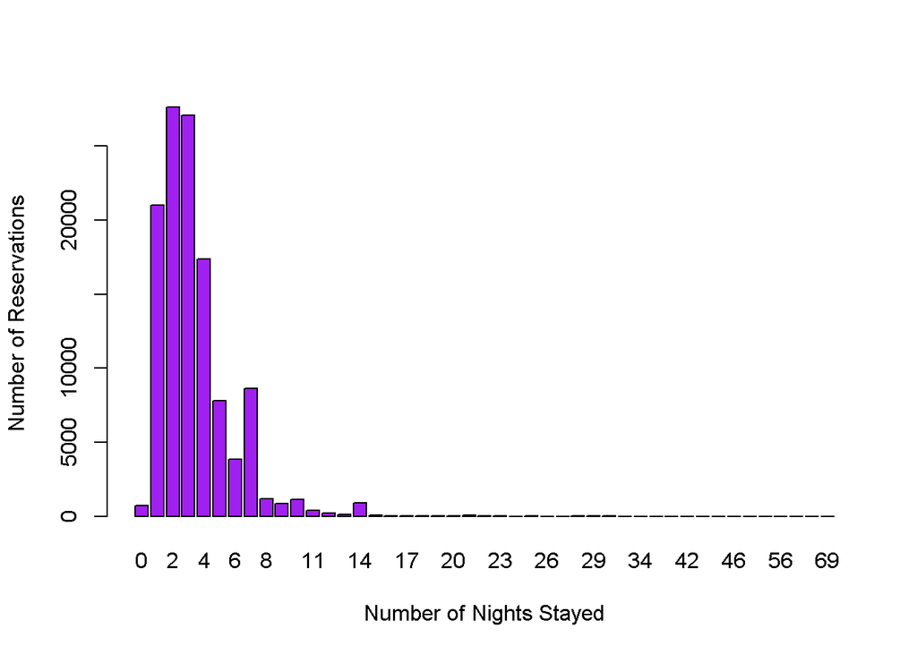

```r
weekendnights <- hotel$stays_in_weekend_nights
weekdaynights <- hotel$stays_in_week_nights
totalnights <-weekendnights+weekdaynights

totalnights <- as.factor(totalnights)

plot(totalnights,ylab="Number of Reservations", xlab="Number of Nights Stayed", col="purple")
```

## How big are the groups that are staying? Here, we are looking to find data related to group size. Since the current data has people grouped into three different columns (adults, children and babies) we will first create a variable to look at the total number of people per group. From this, we will look to compare group size to other vairables.

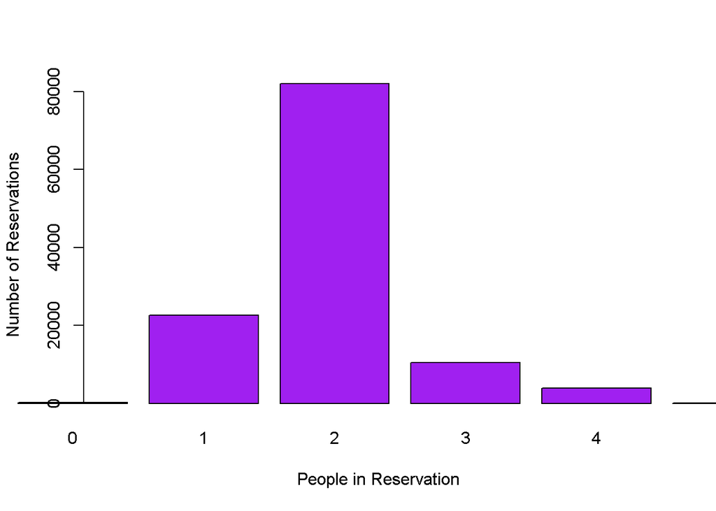

```r
adults <-hotel$adults
children <-hotel$children
babies <- hotel$babies
groupsize <-adults+children+babies

groupsize <- as.factor(groupsize)

plot(groupsize, xlim=c(1,6),ylab="Number of Reservations", xlab="People in Reservation", col="purple")
```

```r
meanadrbygroup <- round(tapply(hotel$adr,groupsize, mean, na.rm=TRUE), 3)

meanadrbygroup
```

```
##       0       1       2       3       4       5       6      10      12      20
##  10.456  81.551  98.036 143.783 186.361 212.371   0.000  47.500 108.805   0.000
##      26      27      40      50      55
##   0.000   0.000   0.000   0.000   0.000
```

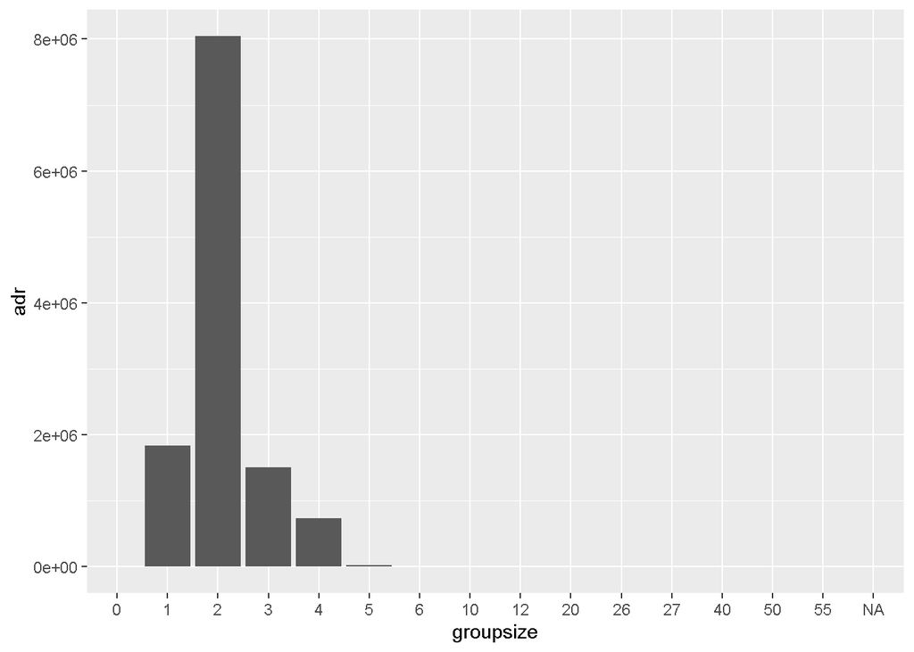

```r
ggplot(hotel, aes(x=groupsize, y=adr))+ geom_bar(stat = "identity")
```

```r
 ##Not sure what graph to do here but theres something here
```

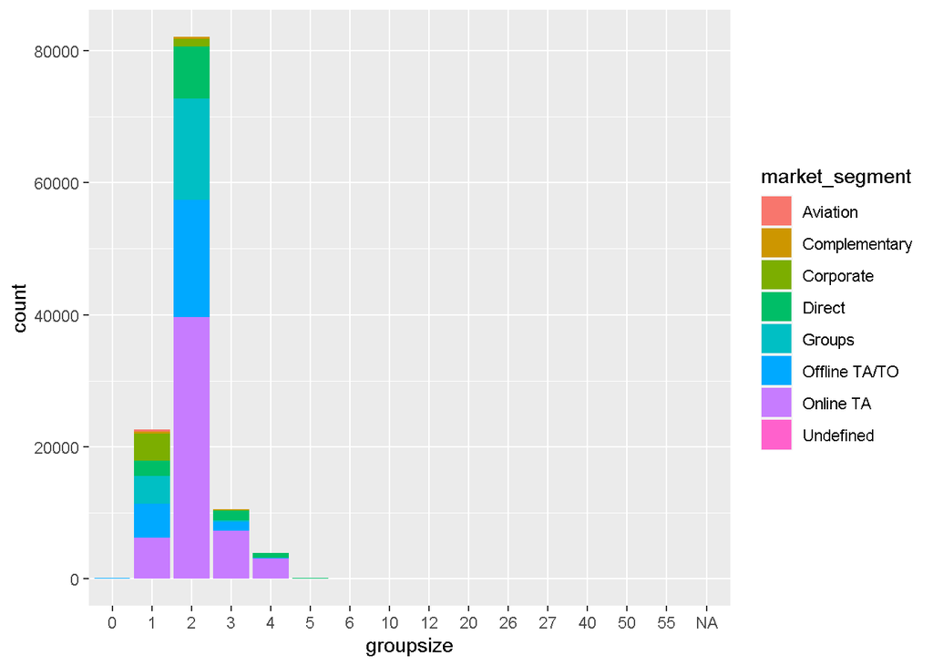

```r
library(ggplot2)

ggplot(hotel, aes(x=groupsize, fill=market_segment)) + geom_bar(position = "stack")
```

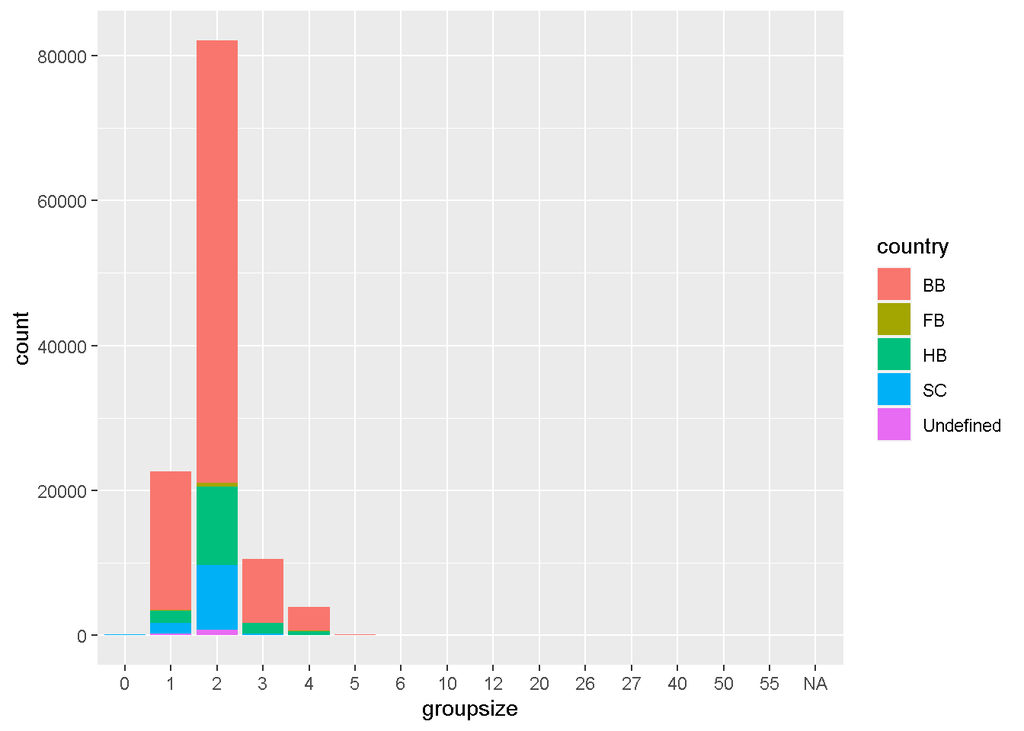

```r
ggplot(hotel, aes(x=groupsize, fill=country)) + geom_bar(position = "stack")
```

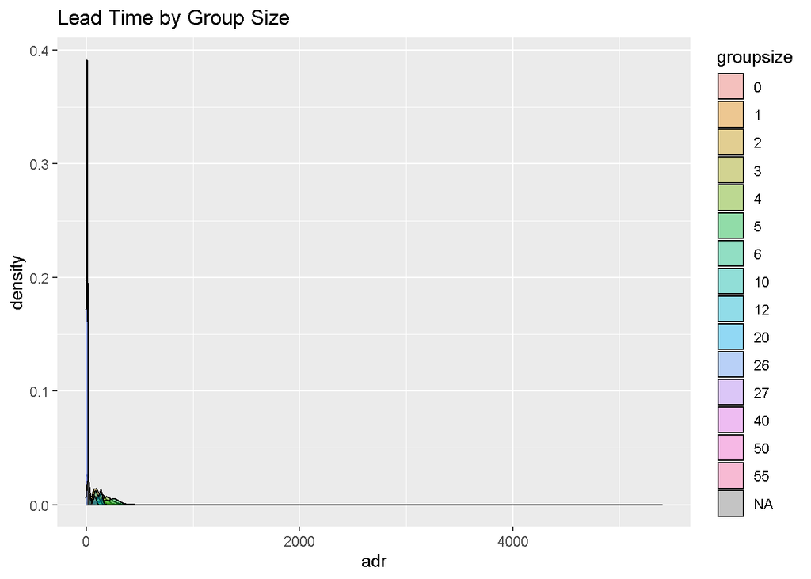

```r
ggplot(hotel, aes(x=adr, fill=groupsize)) + geom_density(alpha=0.4) + labs(title="Lead Time by Group Size") # This is obviously a bad graph just trying some things out
```

## Do Kids cause more special requests? Here, we will look to see if number of children + babies is related to the number of special requests.

```r
mean(hotel$total_of_special_requests, na.rm=TRUE)
```

```
## [1] 0.5713628
```

```r
nonadults<-children+babies

#Basically what im looking to do here is find out whether children and babies increase number of speical requests. Any ideas?
```

# 4 TBD (Jacob Code)

## 4.1 Average Price Per Person

```r
priceperperson<-hotel$adr*groupsize
```

## 4.2 Avg Daily Rate by Type of Hotel

```r
mean(hotel$adr[hotel$hotel == "Resort Hotel"]) # avg daily rate for resort hotel
```

```
## [1] 94.95293
```

```r
mean(hotel$adr[hotel$hotel == "City Hotel"]) # avg daily rate for resort hotel
```

```
## [1] 105.3045
```

## 4.3 Does the type of hotel influence number of car parking spaces?

Not sure how deep this could go but this would more so be relevant for hotels maximizing their space. How many parking spaces should they have / could they utilize spare space another way?

```r
summary(hotel$required_car_parking_spaces)
```

```
##    Min. 1st Qu.  Median    Mean 3rd Qu.    Max.
## 0.00000 0.00000 0.00000 0.06252 0.00000 8.00000
```

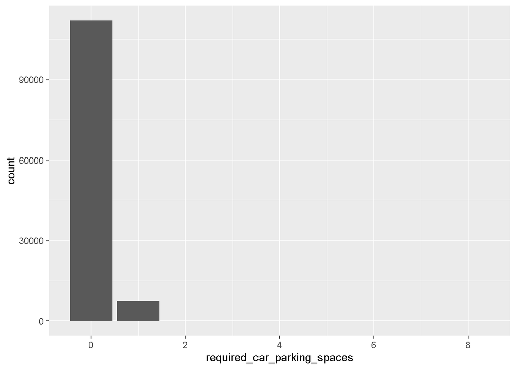

```r
ggplot(data=hotel) + geom_bar(mapping = aes(required_car_parking_spaces)) # just checking # of parking spaces alone first
```

Update: I’m not overly interested in exploring the number of required parking spaces anymore. The **vast** majority of hotel guests require 0 parking spaces (which makes sense – they’re on vacation after all).

## 4.4 Does the time of year influence the number of special requests?

## 4.5 Is there a linear relationship between avg daily rate and special requests

```r
lm_SpecReq_ADR <- lm(adr ~ total_of_special_requests, data=hotel) # create linear model b/w special requests and adr
summary(lm_SpecReq_ADR)
```

```
##
## Call:
## lm(formula = adr ~ total_of_special_requests, data = hotel)
##
## Residuals:
##    Min     1Q Median     3Q    Max
## -139.5  -31.0   -6.6   23.4 5304.4
##
## Coefficients:
##                           Estimate Std. Error t value Pr(>|t|)
## (Intercept)                95.5600     0.1776   538.1   <2e-16 ***
## total_of_special_requests  10.9757     0.1817    60.4   <2e-16 ***
## ---
## Signif. codes:  0 '***' 0.001 '**' 0.01 '*' 0.05 '.' 0.1 ' ' 1
##
## Residual standard error: 49.78 on 119388 degrees of freedom
## Multiple R-squared:  0.02965,    Adjusted R-squared:  0.02964
## F-statistic:  3648 on 1 and 119388 DF,  p-value: < 2.2e-16
```

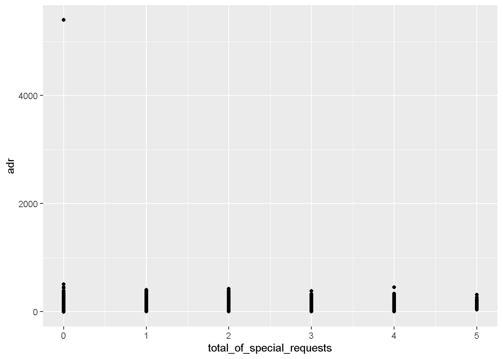

```r
ggplot(data = hotel) + geom_point(mapping = aes(total_of_special_requests, adr))
```

## 4.6 Relationship between reservation status and demographics of guests (aduls/children/babies, country)

# 5 Time of Year

## 5.1 Do Holidays impact ADR?

```r
mean(hotel$adr) #Find Adr on average
```

```
## [1] 101.8311
```

```r
tableJuly4 = hotel[hotel$arrival_date_month == "July" & hotel$arrival_date_day_of_month== 3 | hotel$arrival_date_day_of_month==4,] #Create Table to isolate specifc columns that we want

round(mean(tableJuly4$adr, na.rm= TRUE),2) #Find mean for that holiday
```

```
## [1] 100.77
```

```r
tablenewyearseve = hotel[hotel$arrival_date_month == "December" & hotel$arrival_date_day_of_month== 31,]
round(mean(tablenewyearseve$adr, na.rm= TRUE),2) #repeat
```

```
## [1] 129.74
```

```r
tableXmas = hotel[hotel$arrival_date_month == "December" & hotel$arrival_date_day_of_month== 24 | hotel$arrival_date_day_of_month==25,]
round(mean(tableXmas$adr, na.rm= TRUE),2)
```

```
## [1] 102.82
```

```r
tableValentines = hotel[hotel$arrival_date_month == "February" & hotel$arrival_date_day_of_month== 13 | hotel$arrival_date_day_of_month==14,]
round(mean(tableValentines$adr, na.rm= TRUE),2)
```

```
## [1] 100.08
```

## 5.2 Does Resort type impact ADR on holidays?

```r
tableResort = hotel[hotel$hotel == "Resort Hotel",] #Here we are doing the same code as above, but also isolation for type of hotel to identify whether this is a hotel specifc problem
mean(tableResort$adr)
```

```
## [1] 94.95293
```

```r
tableJuly4Resort = hotel[hotel$arrival_date_month == "July" & hotel$arrival_date_day_of_month== 3 | hotel$arrival_date_day_of_month==4 & hotel$hotel== "Resort Hotel",]

round(mean(tableJuly4Resort$adr, na.rm= TRUE),2)
```

```
## [1] 97.87
```

```r
tableCity = hotel[hotel$hotel == "City Hotel",]
mean(tableCity$adr)
```

```
## [1] 105.3045
```

```r
tableJuly4City = hotel[hotel$arrival_date_month == "July" & hotel$arrival_date_day_of_month== 3 | hotel$arrival_date_day_of_month==4 & hotel$hotel== "City Hotel",]

round(mean(tableJuly4City$adr, na.rm= TRUE),2)
```

```
## [1] 105.57
```

```r
tableXmasCity = hotel[hotel$arrival_date_month == "December" & hotel$arrival_date_day_of_month== 24 | hotel$arrival_date_day_of_month==25 & hotel$hotel=="City Hotel",]
round(mean(tableXmasCity$adr, na.rm= TRUE),2)
```

```
## [1] 105.72
```

```r
TableXmasResort = hotel[hotel$arrival_date_month == "December" & hotel$arrival_date_day_of_month== 24 | hotel$arrival_date_day_of_month==25 & hotel$hotel=="Resort Hotel",]
round(mean(TableXmasResort$adr, na.rm= TRUE),2)
```

```
## [1] 93.64
```

From the above information we can also see that the problem is not hotel specifc. Both City and Resort hotels charge roughly the same ADR overall throughout the year as they do on a few key holidays (shown here are Christmas and July 4th)

# 6 Type of Client

## 6.1 Which clients have the highest adr?

## 6.2 Which clients have the most special requests?

## 6.3 Which clients have the highest cancellation rate

# 7 Summary

*adr*: average daily rate as defined by dividing the sum of all lodging transactions by the total number of staying nights *required_car_parking_spaces*: number of car parking spaces required by the customer *total_of_special_requests*: number of special requests made by the customer (e.g. twin bed or high floor) *reservation_status*: reservation last status, assuming one of three categories: Canceled – booking was canceled by the customer; Check-Out – customer has checked in but already departed; No-Show – customer did not check-in and did inform the hotel of the reason why *reservation_status_date*: date at which the last status was set. This variable can be used in conjunction with the ReservationStatus to understand when was the booking canceled or when did the customer checked-out of the hotel

```r
summary(hotel$adr)
```

```
##    Min. 1st Qu.  Median    Mean 3rd Qu.    Max.
##   -6.38   69.29   94.58  101.83  126.00 5400.00
```

```r
summary(hotel$required_car_parking_spaces)
```

```
##    Min. 1st Qu.  Median    Mean 3rd Qu.    Max.
## 0.00000 0.00000 0.00000 0.06252 0.00000 8.00000
```

```r
summary(hotel$total_of_special_requests)
```

```
##    Min. 1st Qu.  Median    Mean 3rd Qu.    Max.
##  0.0000  0.0000  0.0000  0.5714  1.0000  5.0000
```

```r
summary(hotel$reservation_status)
```

```
##  Canceled Check-Out   No-Show
##     43017     75166      1207
```